# Layered shape and multivariate plots with grindr

Vincent Bonhomme

2018-10-28

## Rationale

When it comes to complex graphics, a grammar has proven powerful and `ggplot2` is mastering them all. “Base graphics” provided by the base package `graphics` has still some merits to me yet it may be boring to build exactly what you want. In particular, working with a grouping structure is boring, and using `magrittr`’s pipes is impossible since all graphical primitives are deadends.

Working with a grouping structure is done with `Momocs:::.fac_dispatcher` and piping drawers/layers is solved b systematically (invisibly) propagating the object used for plotting whether it is a single shape, a `Coo` object or something with more components like a `PCA` object.

Here I briefly introduce `grindr` (short for __gr__aphics __i__s __n__ot __d__ead) drawers and layers that helped rewrite graphical functions of Momocs since version `1.2.5` (one released on CRAN). They are still quite experimental and I’m not fully happy yet with the `drawers` (used for plotting shapes) /`layers` (used for multivariate cartesian planes) dichotomy but it may end up as an independant package at some point.

## Drawers

Papers and drawers are used to represent a shape (as a `matrix` of coordinates) or a collection of shapes (as any `Coo` object, namely `Out`, `Opn` or `Ldk`). It all starts with a `paper*` function, the simplest one being `paper`.

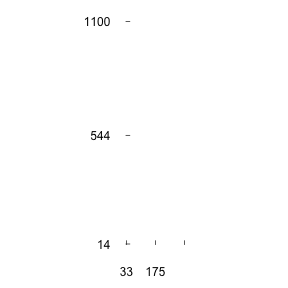

```r
bot[1] %>% paper # single shape
```

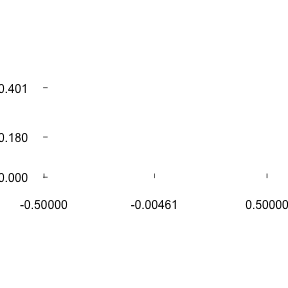

```r
olea %>% paper   # Coo (here Opn) object
```

Close to nothing is obtained but a graph with coordinates is obtained and ready for plotting more shape elements.

[figure not shown]

```r
bot[1] %>% paper %>% draw_outline
```

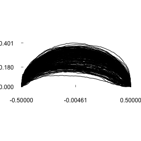

```r
olea %>% paper %>% draw_curve
```

Here we start to see shapes and that’s pretty much what the `stack` function does. This behaviour is possible since all `grindr` functions propagate the object they use(d):

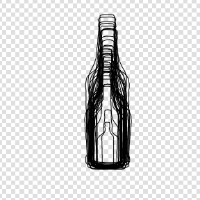

```r
bot %>% paper_chess %>% draw_outline -> x
```

```r
x
```

```
## Out (outlines)
##   - 40 outlines, 162 +/- 21 coords (in $coo)
##   - 3 classifiers (in $fac):
## # A tibble: 40 x 3
##   type   fake     cs
##   <fct>  <fct> <dbl>
## 1 whisky a      335.
## 2 whisky a      307.
## 3 whisky a      220.
## 4 whisky a      245.
## 5 whisky a      277.
## 6 whisky a      210.
## # ... with 34 more rows
##   - also: $ldk
```

Here we used a different paper, and at the exit of the `cheapbabi` pipe we assigned the (otherwise invisibly) returned value to `x`, here the *untouched* `bot`.

All available papers are listed below:

```r
apropos("paper")
```

```
## [1] "paper"       "paper_chess" "paper_dots"  "paper_grid"  "paper_white"
```

Most of the time, we are interested in representing a grouping structure, eg using color. With `cheapbabi` it can be done easily by specifying a column from the `$fac` (see the vignette `Momocs speed dating`, section Architecture). Also more drawers can be add on top of `draw_outline`:

[output not shown]

[output cut: 64 more lines]

[output not shown]

[figure not shown]

```r
bot %>% paper_grid %>%
    draw_outline(~type, bor=col_qual) %>%
    draw_axes %>% draw_centroid %>% draw_firstpoint
```

Let’s come back to grouping specification. It’s quite versatile, you can pass a formula, a factor on the fly, and for colors and others drawers a vectorof the proper length (eg the right number of levels), a palette, etc. See below:

[output not shown]

[output cut: 64 more lines]

[output not shown]

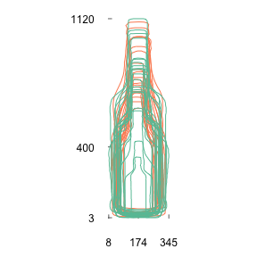

```r
paper(bot) %>% draw_outlines(~type, bor=col_qual)
```

[output not shown]

[output cut: 64 more lines]

[output not shown]

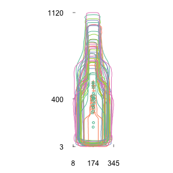

```r
paper(bot) %>%
    draw_outlines(factor(rep(1:5, 8)), bor=col_qual) %>%
    draw_centroid(~type, pch=c(1, 3))
```

For now, I won’t write too much about it, in case large parts are modified, but you should be able to navigate among drawers with `?papers` and `?drawers`

## Layers

When working with multivariate euclidean (eg when `asp=1`) we often need to do again and again the same plot to explore the resulting data, for instance drawing convex hulls, confidence ellipses, etc. I implemented this layered strategy mostly to generalize former `plot.PCA` and reuse large parts.

```r
x <- bot %>% efourier(6) %>% PCA
# plot_PCA(x, ~type) %>%
#     layer_fullframe %>%
#     layer_morphospace %>%
#     layer_points %>% layer_chull %>%
#     layer_eigen %>% layer_legend
```

It works pretty much the same way as `drawers`, you can access the full list with `apropos("layer_")` and `?layers`.

Here again, I’ll write more once `grindr` development will become stable.

**All suggestions and comments are welcome!**

- Done with love by Vincent Bonhomme `<bonhomme.vincent@gmail.com>`.
- Help/suggestions/review/critics are welcome.
- Sources are [there](https://github.com/vbonhomme/Momocs/tree/master/vignettes)